# Homework 4

```r
library(ggplot2)
library(dplyr)
library(rlang)
```

Cargando el archivo diamonds.csv

```r
diamonds_data <- read.csv("diamonds.csv")
str(diamonds_data)
```

```
'data.frame':   1000 obs. of  10 variables:
 $ carat  : num  0.31 1.5 0.9 1.01 0.33 1.08 1.07 0.33 0.44 1 ...
 $ cut    : chr  "Ideal" "Good" "Premium" "Ideal" ...
 $ color  : chr  "G" "G" "H" "F" ...
 $ clarity: chr  "VS1" "SI2" "VS2" "VS2" ...
 $ depth  : num  62.4 64.3 62.8 60.9 63.2 62 61.6 59.5 62 58.6 ...
 $ table  : num  55 57 58 58 56 55 58 59 57 61 ...
 $ price  : int  802 8190 3810 7411 1109 6779 5453 743 1255 6989 ...
 $ x      : num  4.35 7.29 6.17 6.43 4.45 6.62 6.6 4.53 4.87 6.57 ...
 $ y      : num  4.33 7.2 6.13 6.47 4.44 6.57 6.56 4.48 4.91 6.5 ...
 $ z      : num  2.71 4.66 3.86 3.93 2.81 4.09 4.05 2.68 3.02 3.83 ...
```

1. Dispersión

1.1 Construya un gráfico de dispersión colocando en la estética carat (eje x) versus price (eje y), luego devuelva el gráfico. 1.2 Edite la estética y mapee el color con la variable clarity. 1.3 Devuelva el gráfico con esta modificación.

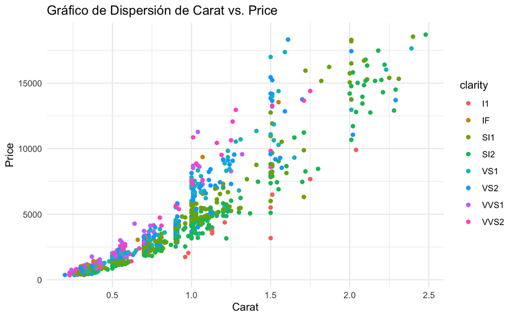

```r
scatter_plot <- ggplot(diamonds_data, aes(x = carat, y = price, color = clarity)) +
  geom_point() +
  labs(title = "Gráfico de Dispersión de Carat vs. Price",
       x = "Carat",
       y = "Price") +
  theme_minimal() +
  scale_color_discrete(name = "clarity")

print(scatter_plot)
```

2. Histograma

2.1 Construya el tipo de geometría histograma para la variable price. Configure el parámetro bins con el valor 40 y devuelva el gráfico. 2.2 Agregue una escala logarítmica de base 10 y devuelva el gráfico para ver la diferencia.

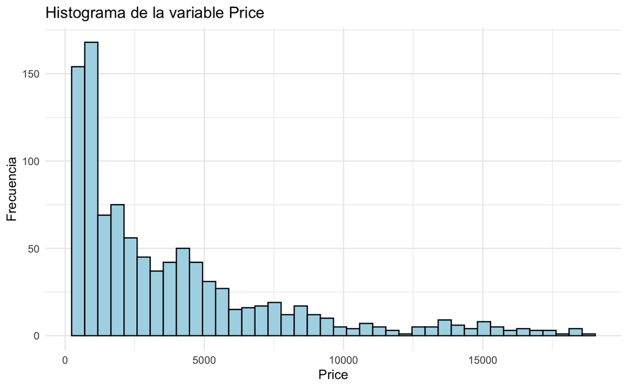

```r
histogram_plot <- ggplot(diamonds_data, aes(x = price)) +
  geom_histogram(bins = 40, color = "black", fill = "lightblue") +
  labs(title = "Histograma de la variable Price",
       x = "Price",
       y = "Frecuencia") +
  theme_minimal()

histogram_plot_base_10 <- ggplot(diamonds_data, aes(x = price)) +
  geom_histogram(bins = 40, color = "black", fill = "lightblue") +
  labs(title = "Histograma de la variable Price",
       x = "Price",
       y = "Frecuencia") +
  theme_minimal() +
  scale_y_log10()


print(histogram_plot)
```

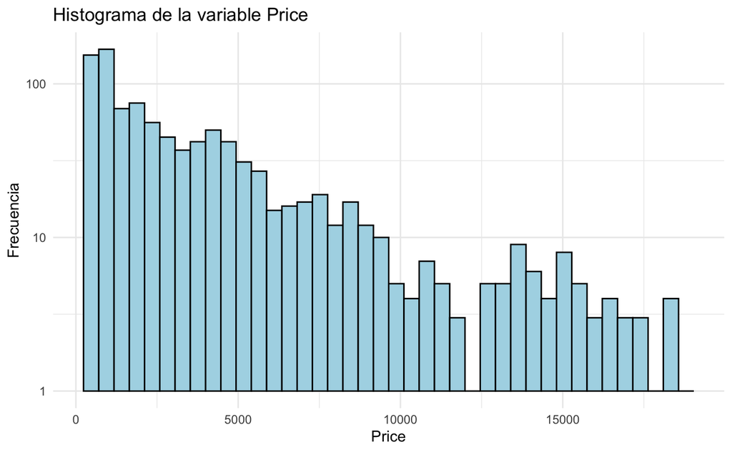

```r
print(histogram_plot_base_10)
```

3. Boxplots

3.1 Construya un gráfico de cajas colocando en la estética la variable cut (eje x) versus price (eje y). Agregue una escala logarítmica por defecto y por último devuelva el gráfico. 3.2 Edite el color de cada caja con el parámetro fill dentro de la estética y asignando la variable cut. Por último devuelva el gráfico.

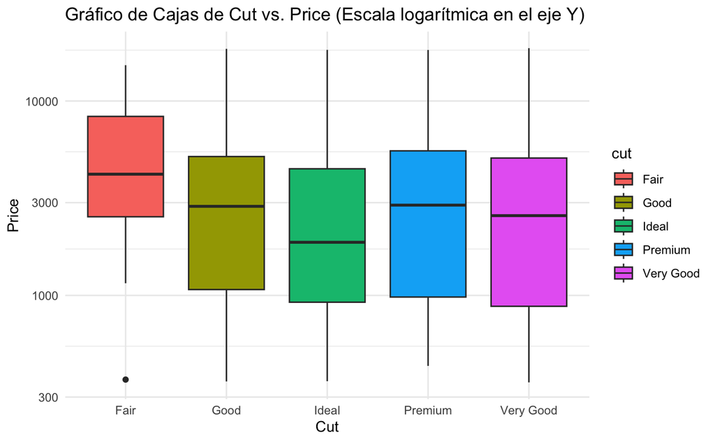

```r
boxplot_plot <- ggplot(diamonds_data, aes(x = cut, y = price, fill = cut)) +
  geom_boxplot() +
  labs(title = "Gráfico de Cajas de Cut vs. Price (Escala logarítmica en el eje Y)",
       x = "Cut",
       y = "Price") +
  theme_minimal() +
  scale_y_log10()

print(boxplot_plot)
```

4.Faceting

4.1 Filtre diamonds por la variable price que sea mayor a 1000 y por cut que contenga las categorías Good, Ideal y Premium. Luego asigne el resultado a la variable filtered_price. Dado que cut debe tomar en cuenta tres categorías específicas puede hacer uso del pipe %in% 4.2 Utilice la variable filtered_price para construir un gráfico de barras, en la estética configure x = cut, y = depth. 4.3 Por último aplique faceting para la variable clarity y devuelva la parcela de gráficos. 4.4 Edite la estética y configure el parámetro fill con la variable clarity. Luego devuelva la parcela de gráficos con esta modificación.

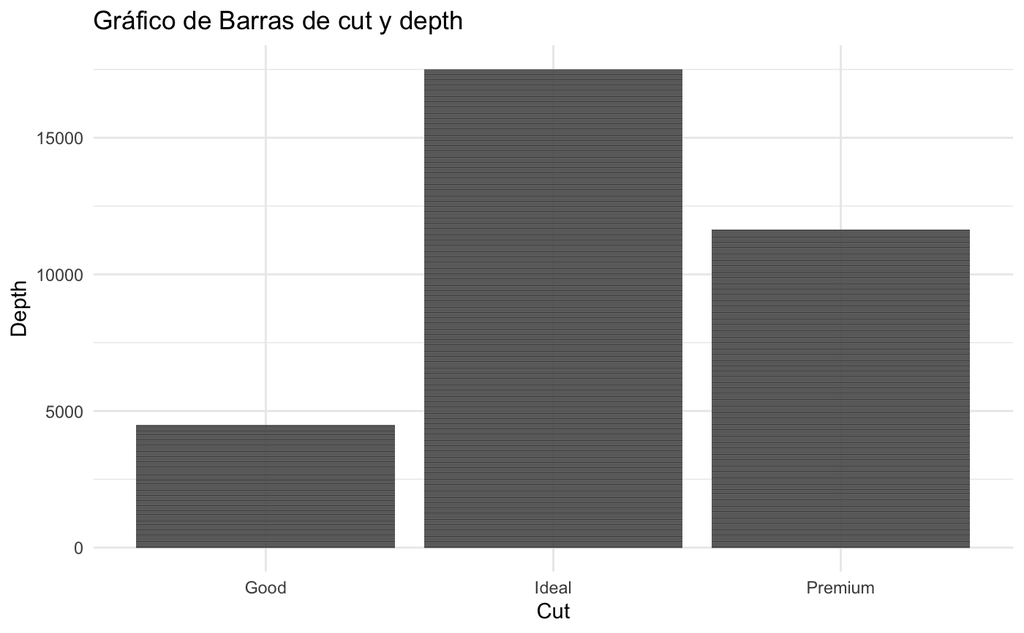

```r
filtered_price <- diamonds_data %>%
  filter(price > 1000, cut %in% c("Good", "Ideal", "Premium"))

bar_plot_filtered_price_1 <- ggplot(filtered_price, aes(x = cut, y = depth)) +
  geom_bar(stat = "identity") +
  labs(title = "Gráfico de Barras de cut y depth",
       x = "Cut",
       y = "Depth") +
  theme_minimal()

print(bar_plot_filtered_price_1)
```

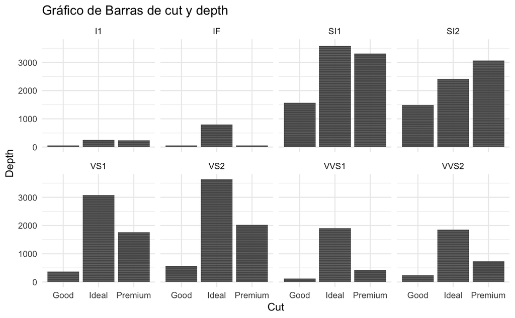

```r
bar_plot_filtered_price_2 <- ggplot(filtered_price, aes(x = cut, y = depth)) +
  geom_bar(stat = "identity") +
  labs(title = "Gráfico de Barras de cut y depth",
       x = "Cut",
       y = "Depth") +
  theme_minimal() +
  facet_wrap(~clarity, ncol = 4)

print(bar_plot_filtered_price_2)
```

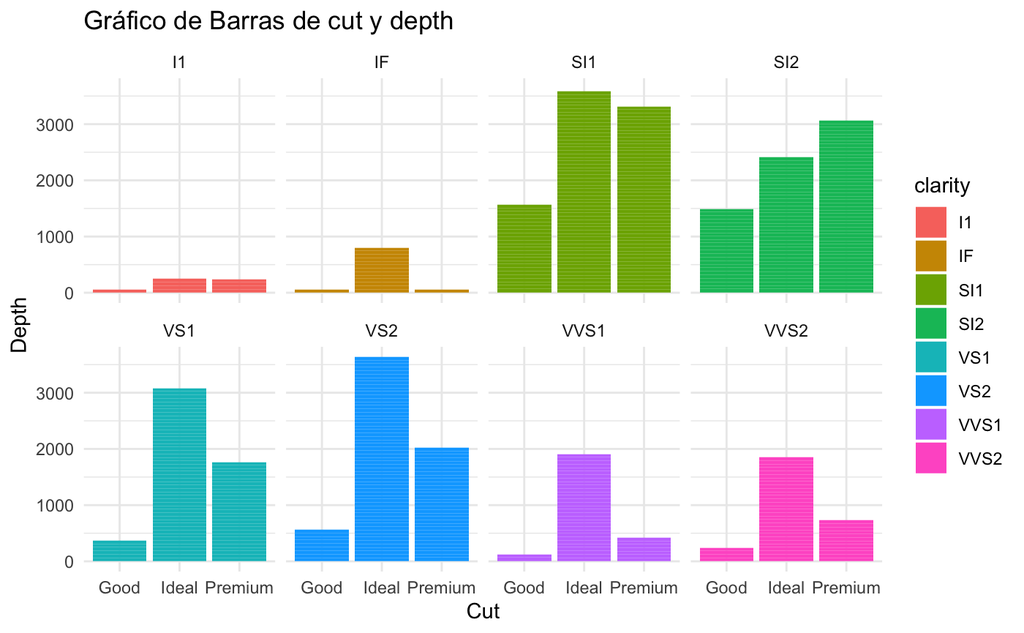

```r
bar_plot_filtered_price_3 <- ggplot(filtered_price, aes(x = cut, y = depth, fill = clarity)) +
  geom_bar(stat = "identity") +
  labs(title = "Gráfico de Barras de cut y depth",
       x = "Cut",
       y = "Depth") +
  theme_minimal() +
  facet_wrap(~clarity, ncol = 4)

print(bar_plot_filtered_price_3)
```

Grouping and summarizing

1. Utilice diamonds para construir un agrupamiento por la variable cut, luego aplique summarize para encontrar la media de las variables x, y, z (los nombres de los valores sumarizados serán mediaX, mediaY, mediaZ, respectivamente). Asigne el resultado a la variable median_dimension_diamond, por último imprima la variable.

```r
median_dimension_diamond <- diamonds_data %>%
  group_by(cut) %>%
  summarise(mediaX = mean(x),
            mediaY = mean(y),
            mediaZ = mean(z))

print(median_dimension_diamond)
```

| cut | mediaX | mediaY | mediaZ |
| --- | --- | --- | --- |
| Fair | 6.417143 | 6.335357 | 4.147857 |
| Good | 5.819053 | 5.834632 | 3.635579 |
| Ideal | 5.530775 | 5.541400 | 3.416825 |
| Premium | 5.916070 | 5.873152 | 3.591284 |
| Very Good | 5.665955 | 5.696545 | 3.512318 |

2. Utilice diamonds para filtrar por la variable cut igual a Premium. Luego agrupe por la variable clarity y utilice summarize para encontrar minimo y maximo de price (los nombres de los valores sumarizados serán minPrice y maxPrice, respectivamente). Asigne el resultado a la variable cut_premium e imprima el valor de la variable.

```r
cut_premium <- diamonds_data %>%
  filter(cut == "Premium") %>%
  group_by(clarity) %>%
  summarise(minPrice = min(price),
            maxPrice = max(price))


print(cut_premium)
```

| clarity | minPrice | maxPrice |
| --- | --- | --- |
| I1 | 2046 | 9905 |
| IF | 694 | 1020 |
| SI1 | 500 | 18295 |
| SI2 | 434 | 16783 |
| VS1 | 523 | 17642 |
| VS2 | 454 | 17433 |
| VVS1 | 552 | 11279 |
| VVS2 | 698 | 8722 |

3. Construya un gráfico de barras y utilice cut_premium como set de datos, configure x=clarity, y=maxPrice y el color de relleno (fill) con la variable clarity. Por último devuelva el gráfico.

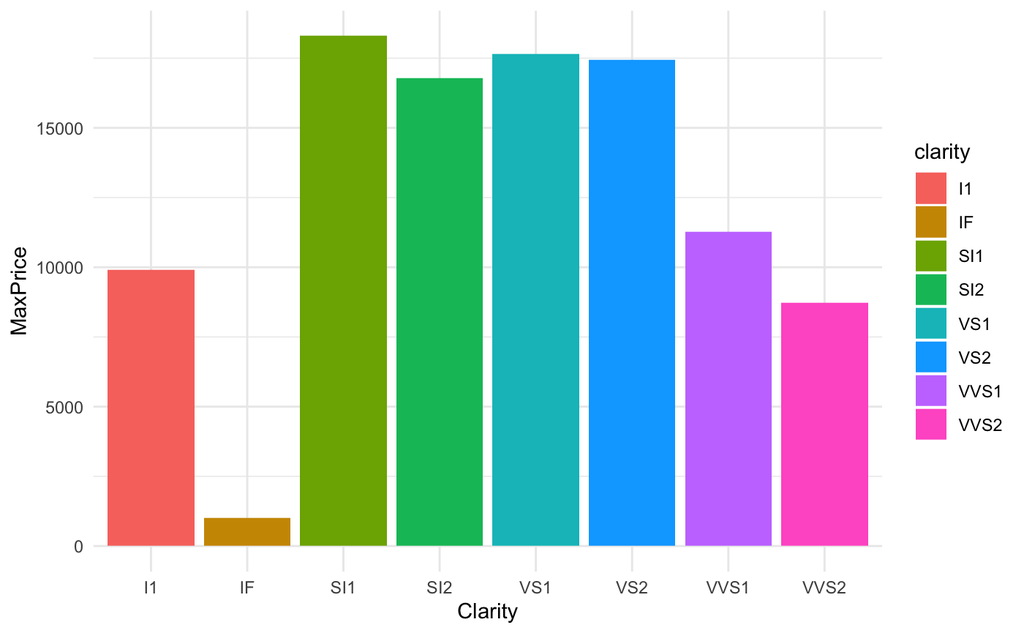

```r
bar_plot_premium <- ggplot(cut_premium, aes(x = clarity, y = maxPrice, fill = clarity)) +
  geom_bar(stat = "identity") +
  labs(x = "Clarity",
       y = "MaxPrice") +
  theme_minimal()


print(bar_plot_premium)
```